# Настройка POP3/IMAP сервера

Лабораторная работа №9

Элсаиед Адел

Российский университет дружбы народов, Москва, Россия

4 января 2026

# Цель и задачи работы

## Цель лабораторной работы

Приобретение практических навыков установки и базовой настройки почтового сервера с поддержкой протоколов POP3 и IMAP.

# Выполнение работы

## Настройка поддерживаемых протоколов

В конфигурационном файле Dovecot задан список используемых почтовых протоколов — IMAP и POP3.

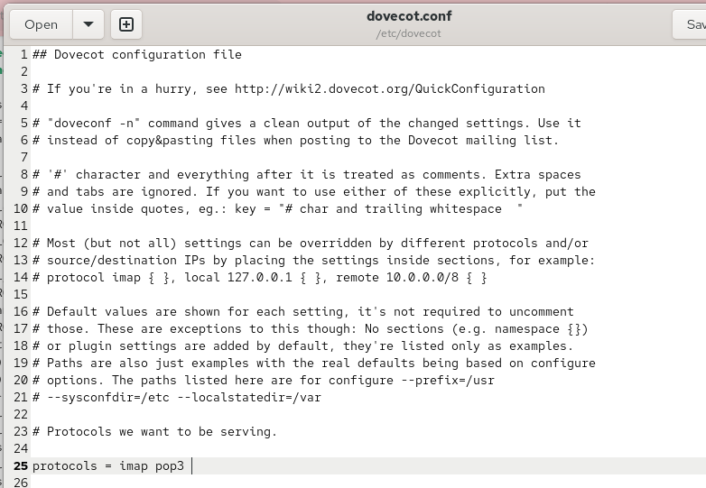

Настройка протоколов Dovecot

## Настройка аутентификации пользователей

В конфигурации Dovecot выбран механизм аутентификации plain, обеспечивающий работу с системной базой пользователей.

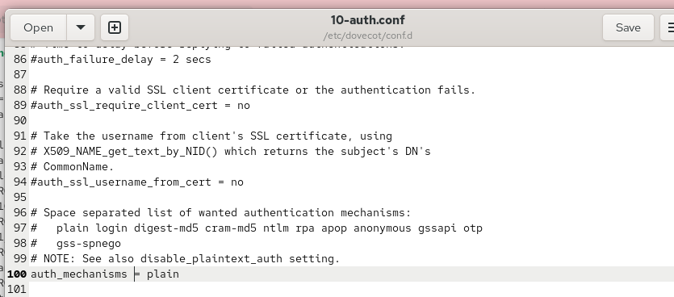

Настройка аутентификации

## Источники учётных данных

Для аутентификации используется PAM, а информация о пользователях извлекается из системного файла passwd.

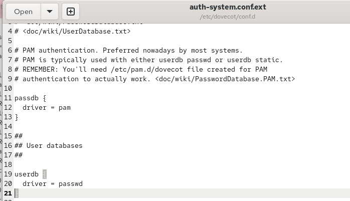

Источники аутентификации

## Настройка почтовых ящиков

В качестве формата хранения почты выбран Maildir, размещаемый в домашнем каталоге пользователя.

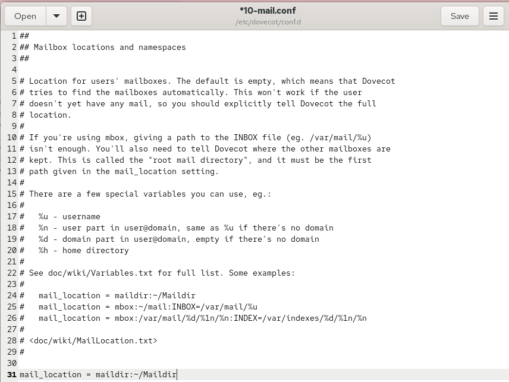

Настройка Maildir

## Настройка межсетевого экрана

В межсетевом экране разрешена работа сервисов POP3, POP3S, IMAP и IMAPS.

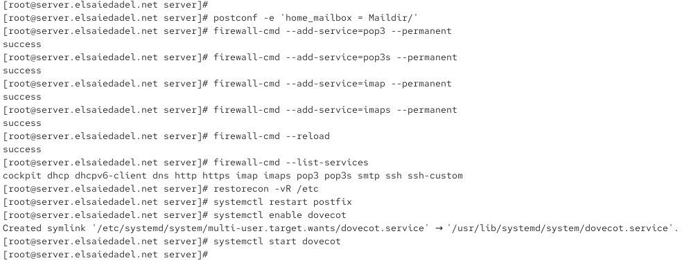

Настройка firewall

## Мониторинг работы почтовых служб

В процессе тестирования выполнялся мониторинг логов почтовых служб Postfix и Dovecot.

[figure not shown]

Мониторинг maillog

## Проверка доставки почты на сервере

Просмотр содержимого Maildir подтвердил успешную доставку тестовых писем локальному пользователю.

[figure not shown]

Просмотр Maildir

## Использование doveadm

[figure not shown]

doveadm mailbox list

## Настройка почтового клиента

На виртуальной машине Client установлен и настроен почтовый клиент Evolution для работы с IMAP и SMTP.

[figure not shown]

Настройка Evolution

## Получение тестовых сообщений

Отправленные тестовые письма успешно доставлены и отображены в папке «Входящие».

[figure not shown]

Тестовые письма

## Проверка POP3 через Telnet

Работа протокола POP3 проверена с использованием Telnet: выполнен вход, просмотр и удаление писем.

[figure not shown]

POP3 через Telnet

## Копирование конфигурационных файлов

Конфигурационные файлы Dovecot сохранены в каталог provisioning для последующей автоматизации развёртывания.

[figure not shown]

Копирование конфигураций

## Provisioning-скрипты

В provisioning-скрипты добавлены действия по установке, настройке и запуску почтовых служб на сервере и клиенте.

[figure not shown]

Provisioning mail.sh

# Выводы

## Вывод

В ходе лабораторной работы был настроен и протестирован почтовый сервер на базе Postfix и Dovecot. Обеспечена доставка и получение электронной почты по протоколам SMTP, IMAP и POP3. Проверена работа почтовых клиентов и автоматизирована настройка почтовой подсистемы с использованием provisioning-скриптов.